# Regression_example

hyo

2020 5 25

### 문제1

#### 라이브러리 regbook 안에 있는 aflength 데이터를 사용하여 회귀분석을 시행하여라

- `install.packages("devtools");library(devtools);install_github("regbook/regbook")` 실행 후 데이터 사용

```r
#install.packages("devtools")
#library(devtools)
#install_github("regbook/regbook")
library(regbook)
```

##### 1) 데이터를 head()를 사용하여 확인하고 종속변수를 foot, 설명변수를 forearm으로 하여 산점도를 확인해보고 대략적인 상관관계를 설명하시오

```r
head(aflength)
```

```
##   foot forearm gender
## 1  233     232      M
## 2  242     241      M
## 3  242     241      M
## 4  238     242      M
## 5  246     243      M
## 6  248     246      M
```

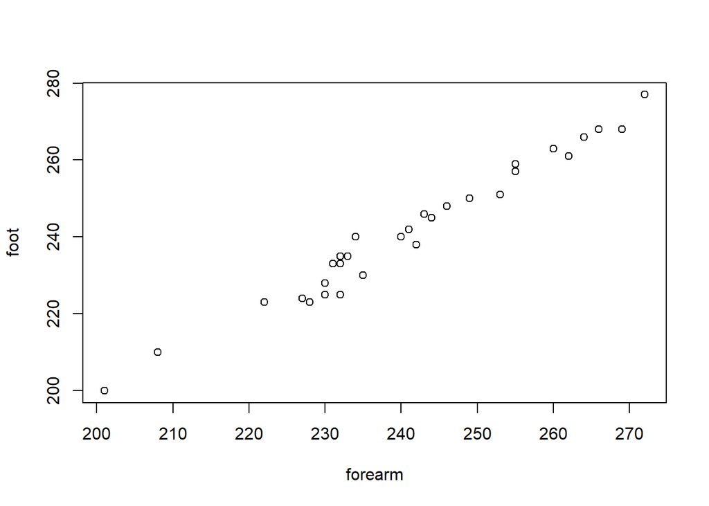

```r
plot(foot~forearm, data=aflength) #양의 상관관계
```

##### 2) 위의 두 변수간의 상관관계를 수치로 구하고 두변수간의 관계를 설명하시오

```r
cor(aflength$foot, aflength$forearm)
```

```
## [1] 0.9859492
```

```r
#-1~1 사이 값으로 0,985는 1에 매우 가까우며 높은 양의 상관관계를 갖는다
```

#### 3) 단순 회귀 분석을 시행하시오

- plot 및 분석 결과 설명

```r
# foot = -12.419 + 1.052*forearm
# forearm의 p-value값을 확인 해보면 <2e-16으로 매우 유의한 값을 갖는 것을 확인 할 수 있다
# forearm이 한단위 증가함에 따라 foot의 값은 평균적으로 1.052만큼 증가한다
# Adjusted R-squared:  0.9712 이므로 선형관계가 높음을 알수 있다
aflength.lm <- lm(foot~forearm, data=aflength)
summary(aflength.lm)
```

```
##
## Call:
## lm(formula = foot ~ forearm, data = aflength)
##
## Residuals:
##     Min      1Q  Median      3Q     Max
## -6.8117 -2.4320  0.7138  1.8205  6.0828
##
## Coefficients:
##              Estimate Std. Error t value Pr(>|t|)
## (Intercept) -12.41920    7.86284  -1.579    0.125
## forearm       1.05272    0.03256  32.328   <2e-16 ***
## ---
## Signif. codes:  0 '***' 0.001 '**' 0.01 '*' 0.05 '.' 0.1 ' ' 1
##
## Residual standard error: 3.015 on 30 degrees of freedom
## Multiple R-squared:  0.9721, Adjusted R-squared:  0.9712
## F-statistic:  1045 on 1 and 30 DF,  p-value: < 2.2e-16
```

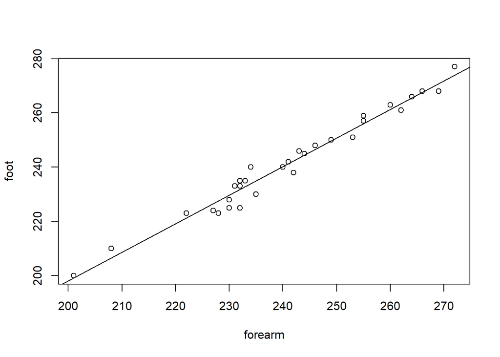

```r
# plot
plot(foot~forearm, data=aflength)
abline(aflength.lm)
```

### 문제2

#### 중고차 가격자료 `usedcars`에 대한 회귀분석에서 가격(price)에 대해

- 1. 각 회귀계수가 0이라는 가설에 대한 t검정을 하여라
- 2. 각 회귀계수에 대한 95% 신뢰구간을 구하여라

```r
# 귀무가설 : 독립변수와 종속변수간의 유의한 상관관계가 존재하지않는다
# 대립가설 : 독립변수와 종속변수간의 유의한 상관관계가 존재한다
# p-value값을 살펴보면 cc를 제외한 변수는 < 0.05이므로 유의수준 5%하에서 귀무가설을 기각할만한 충분한 근거가된다. 따라서 종속변수와 독립변수간의 유의한 상관관계가 있다고 말 할 수 있지만 CC변수는 귀무가설을 기각하지 못한다

#
data(usedcars)
usedcars.lm = lm(price ~ .,usedcars)
summary(usedcars.lm)
```

```
##
## Call:
## lm(formula = price ~ ., data = usedcars)
##
## Residuals:
##     Min      1Q  Median      3Q     Max
## -177.35  -63.91   -0.99   70.34  212.69
##
## Coefficients:
##               Estimate Std. Error t value Pr(>|t|)
## (Intercept)  5.253e+02  3.998e+02   1.314 0.200823
## year        -5.800e+00  9.283e-01  -6.247 1.55e-06 ***
## mileage     -2.263e-03  7.211e-04  -3.138 0.004324 **
## cc           3.888e-01  2.022e-01   1.923 0.065958 .
## automatic    1.653e+02  3.986e+01   4.147 0.000339 ***
## ---
## Signif. codes:  0 '***' 0.001 '**' 0.01 '*' 0.05 '.' 0.1 ' ' 1
##
## Residual standard error: 101.1 on 25 degrees of freedom
## Multiple R-squared:  0.9045, Adjusted R-squared:  0.8892
## F-statistic: 59.21 on 4 and 25 DF,  p-value: 2.184e-12
```

```r
#R에서 회귀계수에 대한 신뢰구간은 다음과 같이 얻을 수 있다
confint(usedcars.lm)
```

```
##                     2.5 %        97.5 %
## (Intercept) -2.981256e+02  1.348699e+03
## year        -7.711605e+00 -3.887669e+00
## mileage     -3.748021e-03 -7.776672e-04
## cc          -2.763072e-02  8.052054e-01
## automatic    8.322275e+01  2.474025e+02
```

### 문제3

#### 위 데이터에 대한 회귀분석 문제에서 Y의 평균에 대한 신뢰구간과 새로운 Y값에 대한 예측구간을 다음 경우에 대해 각각 구해보자

- year = 60, mileage = 100000, cc = 2000, automatic = 1

```r
# 새로운 값을 이용하여 예측할 때에는 새로운 데이터프레임을 만들어야한다
nw = data.frame(year = 60, mileage = 100000, cc = 2000, automatic = 1)
nw
```

```
##   year mileage   cc automatic
## 1   60   1e+05 2000         1
```

```r
#95% 신뢰구간 (821.1568, 966.6666)
predict(usedcars.lm,newdata=nw,interval = "confidence")
```

```
##        fit      lwr      upr
## 1 893.9117 821.1568 966.6666
```

```r
#95% 예측구간 (673.3444, 1114.479()
predict(usedcars.lm,newdata=nw,interval = "prediction")
```

```
##        fit      lwr      upr
## 1 893.9117 673.3444 1114.479
```

### 문제4

#### 자료 ’hald’는 1932년 미국 화학공학 학회지에 발표된것으로, 시멘트가 굳을때 발생하는 열량에 시멘트의 네가지 성분들이 미치는 영향을 분석한 것이다. `data(hald)`를 사용하여 y에 대해 x변수들의 다중공선성의 유무를 판단하시오

```r
data(hald)
hald.lm1 = lm(y~.,hald)
# x1의 p-value값이 0.1 기준으로 유의한 변수라고 할 수 있다
summary(hald.lm1)
```

```
##
## Call:
## lm(formula = y ~ ., data = hald)
##
## Residuals:
##     Min      1Q  Median      3Q     Max
## -3.1750 -1.6709  0.2508  1.3783  3.9254
##
## Coefficients:
##             Estimate Std. Error t value Pr(>|t|)
## (Intercept)  62.4054    70.0710   0.891   0.3991
## x1            1.5511     0.7448   2.083   0.0708 .
## x2            0.5102     0.7238   0.705   0.5009
## x3            0.1019     0.7547   0.135   0.8959
## x4           -0.1441     0.7091  -0.203   0.8441
## ---
## Signif. codes:  0 '***' 0.001 '**' 0.01 '*' 0.05 '.' 0.1 ' ' 1
##
## Residual standard error: 2.446 on 8 degrees of freedom
## Multiple R-squared:  0.9824, Adjusted R-squared:  0.9736
## F-statistic: 111.5 on 4 and 8 DF,  p-value: 4.756e-07
```

```r
# vif 값을 살펴 보면 X2와 X4의 값이 가장 큰 것을 확인 할 수 있다.
# 두 변수 사이에 선형종속관계가 존재한다고 판단되어지므로 분석 시 가장 크게 나온 X4의 변수를 제거하고 다시 분석을 진행한다.
vif(hald.lm1)
```

```
##        x1        x2        x3        x4
##  38.49621 254.42317  46.86839 282.51286
```

```r
hald.lm2 = lm(y~x1+x2+x3,hald)
# x1의 p-value값이 0.1 기준으로 유의한 변수라고 할 수 있다
summary(hald.lm2)
```

```
##
## Call:
## lm(formula = y ~ x1 + x2 + x3, data = hald)
##
## Residuals:
##     Min      1Q  Median      3Q     Max
## -3.2543 -1.4726  0.1755  1.5409  3.9711
##
## Coefficients:
##             Estimate Std. Error t value Pr(>|t|)
## (Intercept) 48.19363    3.91330  12.315 6.17e-07 ***
## x1           1.69589    0.20458   8.290 1.66e-05 ***
## x2           0.65691    0.04423  14.851 1.23e-07 ***
## x3           0.25002    0.18471   1.354    0.209
## ---
## Signif. codes:  0 '***' 0.001 '**' 0.01 '*' 0.05 '.' 0.1 ' ' 1
##
## Residual standard error: 2.312 on 9 degrees of freedom
## Multiple R-squared:  0.9823, Adjusted R-squared:  0.9764
## F-statistic: 166.3 on 3 and 9 DF,  p-value: 3.367e-08
```

### 문제5

#### 위 데이터를 dplyr를 활용하여 회귀분석을 시행하시오

- 힌트 : do(reg=lm(Y~X1+X2+X3,data=.))를 통해 회귀식을 구성한다

```r
library(dplyr)
library(broom)
library(devtools)
hald_reg = hald %>% do(reg=lm(y~x1+x2+x3,data=.))
ANOVAreg = hald_reg %>% rowwise %>% do(anova(.$reg))             #ANOVA result
ANOVAreg=as.data.frame(ANOVAreg)
ANOVAreg
```

```
##   Df      Sum Sq     Mean Sq    F value       Pr(>F)
## 1  1 1450.076328 1450.076328 271.264194 4.995767e-08
## 2  1 1207.782266 1207.782266 225.938509 1.107893e-07
## 3  1    9.793869    9.793869   1.832128 2.088895e-01
## 4  9   48.110614    5.345624         NA           NA
```

```r
tidy(hald_reg,reg)
```

```
## # A tibble: 4 x 5
##   term        estimate std.error statistic     p.value
##   <chr>          <dbl>     <dbl>     <dbl>       <dbl>
## 1 (Intercept)   48.2      3.91       12.3  0.000000617
## 2 x1             1.70     0.205       8.29 0.0000166
## 3 x2             0.657    0.0442     14.9  0.000000123
## 4 x3             0.250    0.185       1.35 0.209
```